# Latihan Simulasi Model Data Deret Waktu

G1401211033_Nazuwa Aulia

2023-09-21

```r
library(forecast)
```

## White Noise

Pembangkitan data berpola AR, MA, ARMA, dan banyak proses deret waktu lainnya diawali pembangkitan *white noise*. *White noise* merupakan sederet nilai dari peubah bebas stokastik identik. Oleh karena itu, *white noise* memiliki dua karakteristik penting:

1. *White noise* tidak memiliki autokorelasi (**karena saling bebas**)
2. Nilai harapan dan ragam *white noise* sama (**karena berasal dari peubah acak bebas stokastik identik**)

*White noise* dibangkitkan dari suatu peubah acak, umumnya peubah acak normal.

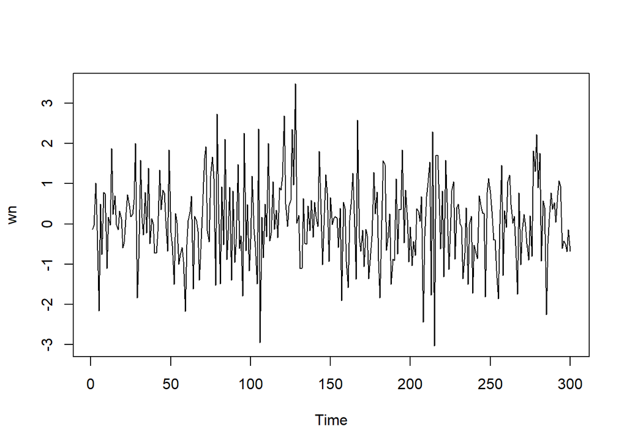

```r
#NOTE kalo misalnya bangkitin datanya lebih besar bakal lebih mendekati ke teoritis
set.seed(033)
wn <- rnorm(300)
ts.plot(wn)
```

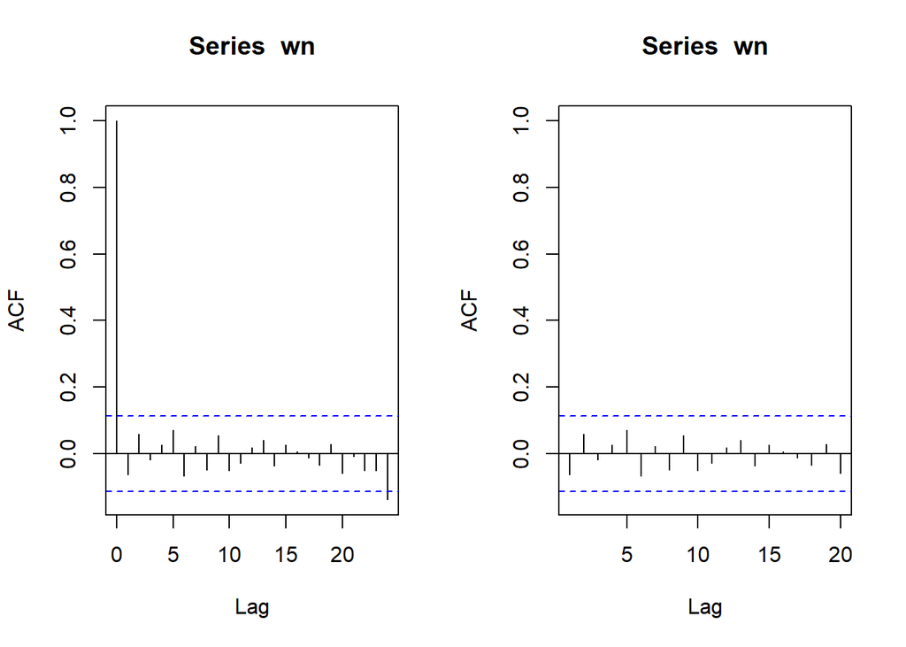

```r
par(mfrow = c(1, 2))
acf(wn)
acf(wn, xlim = c(1, 20))
```

Dapat terlihat bahwa *white noise* tidak memiliki autokorelasi dari ACF. Perhatikan bahwa lag ke-0 adalah korelasi observasi ke-t dengan dirinya sendiri. Nilai korelasi tersebut pasti 1. Sebagai alternatif, lag pertama di plot ACF dapat ditetapkan sebagai 1 (alih-alih 0) dengan menambahkan argumen `xlim(1, lag akhir)`. Plot tersebut dapat disandingkan bersamaan dengan membuat matriks $1 \times 2$ dengan `par(mfrow = c(1,2))`.

## MA(2)

Proses MA dapat dituliskan sebagai berikut:

$$y_{t} = c + e_t + \theta_{1}e_{t-1} + \theta_{2}e_{t-2} + \dots +
\theta_{q}e_{t-q} = c+{e_t+\sum_{i=1}^p \theta_ie_{t-i}}$$
Terlihat bahwa $e_t$, atau *white noise*, berperan penting dalam pembangkitan proses MA.

## Pembangkitan MA(2)

### Membangkitkan nilai MA Manual

```r
set.seed(033)
ma <- wn[2]
```

Nilai-nilai selanjutnya dapat dicari melalui *loop*. Bentuk loop dapat dilihat dari rumus MA(2) yang hendak dibangkitkan:

```r
for(i in 3:300){
   ma[i] <- wn[i] + 0.4 * wn[i - 1] + 0.6 * wn[i-2]
}
ma
```

```
##   [1] -0.040796970           NA  0.912665506  0.221474976 -1.613619077
##   [6] -0.458965633 -1.849768074  0.775675569  0.612865447 -0.330563317
##  [11]  0.180278489 -0.622070865  1.964541612  0.977402389  1.925514489
##  [16]  0.412556489  0.271887865  0.254267147  0.164578663 -0.353331613
##  [21] -0.606860383 -0.243253432  0.574417961  0.923337453  0.803126768
##  [26]  0.583591439  0.797923360  2.378785234 -0.680728030 -0.396569889
##  [31]  0.135612365  0.270921082  0.736793377  0.770788436 -0.072929388
##  [36]  1.775433948 -0.065636272  0.777130675 -0.234732609 -0.643055972
##  [41] -1.010082314 -0.915229200  0.826159857  0.775772586  1.786295441
##  [46]  1.325233745  0.895928245 -0.175738682  1.614741417  0.123416308
##  [51]  0.478840147 -1.840961787 -0.656176535 -0.759094655 -0.820843477
##  [56] -1.147873740 -1.483364988 -1.626380971 -2.897030556 -1.944689106
##  [61] -1.422722659  0.021671271  0.863458942 -1.158085035 -0.041446394
##  [66] -0.814437202 -0.030114853 -1.422477786 -1.033221033 -0.536084453
##  [71]  1.584980385  2.844429286  1.581831975  0.649960163  0.918134378
```

[output cut: 45 more lines]

Selain menggunakan cara di atas, pembangkitan proses MA(2) dapat dilakukan dengan fungsi `arima.sim()` sebagai berikut.

### Membangkitkan MA dengan fungsi

```r
ma2_param <- c(0.4, 0.6)
ma2<- arima.sim(model = list(order = c(0, 0, 2), ma = ma2_param), n = 300)
ma2
```

```
## Time Series:
## Start = 1
## End = 300
## Frequency = 1
##   [1]  0.912665506  0.221474976 -1.613619077 -0.458965633 -1.849768074
##   [6]  0.775675569  0.612865447 -0.330563317  0.180278489 -0.622070865
##  [11]  1.964541612  0.977402389  1.925514489  0.412556489  0.271887865
##  [16]  0.254267147  0.164578663 -0.353331613 -0.606860383 -0.243253432
##  [21]  0.574417961  0.923337453  0.803126768  0.583591439  0.797923360
##  [26]  2.378785234 -0.680728030 -0.396569889  0.135612365  0.270921082
##  [31]  0.736793377  0.770788436 -0.072929388  1.775433948 -0.065636272
##  [36]  0.777130675 -0.234732609 -0.643055972 -1.010082314 -0.915229200
##  [41]  0.826159857  0.775772586  1.786295441  1.325233745  0.895928245
##  [46] -0.175738682  1.614741417  0.123416308  0.478840147 -1.840961787
##  [51] -0.656176535 -0.759094655 -0.820843477 -1.147873740 -1.483364988
```

[output cut: 49 more lines]

## Karakteristik MA(2)

### Plot Time Series

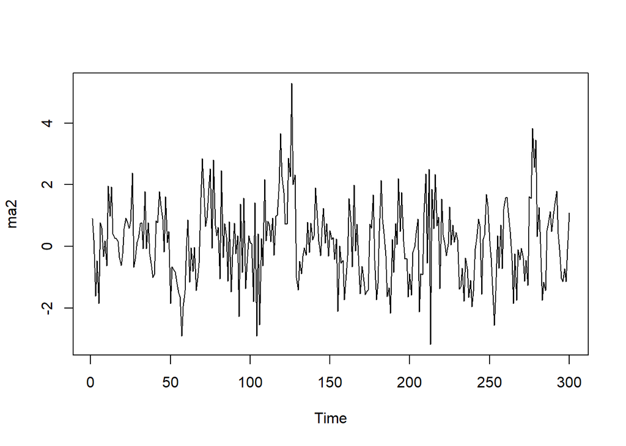

```r
ts.plot(ma2)
```

Berdasarkan plot time series, terlihat bahwa data MA(2) yang dibangkitkan stasioner dalam rataan

### Plot ACF

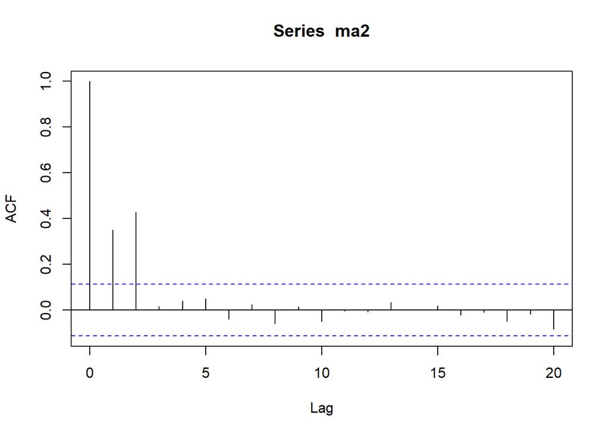

```r
acf(ma2,lag.max = 20)
```

Berdasarkan plot ACF tersebut, terlihat bahwa plot ACF *cuts off* di lag kedua

### Plot PACF

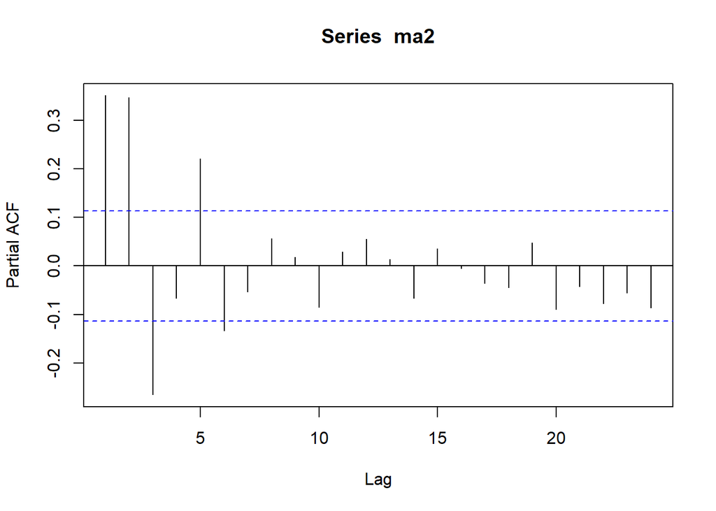

```r
pacf(ma2)
```

Berdasarkan plot PACF tersebut, terlihat bahwa plot PACF cenderung *tails off* dan membentuk gelombang sinus

### Plot EACF

```r
TSA::eacf(ma2)
```

```
## AR/MA
##   0 1 2 3 4 5 6 7 8 9 10 11 12 13
## 0 x x o o o o o o o o o  o  o  o
## 1 x x x o o o o o o o o  o  o  o
## 2 x x x o o o o o o o o  o  o  o
## 3 x x o o x o o o o o o  o  o  o
## 4 x x x o x o o o o o o  o  o  o
## 5 x x o x x o o o o o o  o  o  o
## 6 x x o x o o o o o o o  o  o  o
## 7 x x o x o o x o o o o  o  o  o
```

Berdasarkan pola segitiga nol pada plot EACF, terlihat bahwa segitiga nol berada pada ordo AR(0) dan ordo MA(2)

### Scatter plot Antar Lag

```r
#Yt
yt_ma <- ma2[-1]
yt_ma
```

```
##   [1]  0.221474976 -1.613619077 -0.458965633 -1.849768074  0.775675569
##   [6]  0.612865447 -0.330563317  0.180278489 -0.622070865  1.964541612
##  [11]  0.977402389  1.925514489  0.412556489  0.271887865  0.254267147
##  [16]  0.164578663 -0.353331613 -0.606860383 -0.243253432  0.574417961
##  [21]  0.923337453  0.803126768  0.583591439  0.797923360  2.378785234
##  [26] -0.680728030 -0.396569889  0.135612365  0.270921082  0.736793377
##  [31]  0.770788436 -0.072929388  1.775433948 -0.065636272  0.777130675
##  [36] -0.234732609 -0.643055972 -1.010082314 -0.915229200  0.826159857
##  [41]  0.775772586  1.786295441  1.325233745  0.895928245 -0.175738682
##  [46]  1.614741417  0.123416308  0.478840147 -1.840961787 -0.656176535
##  [51] -0.759094655 -0.820843477 -1.147873740 -1.483364988 -1.626380971
##  [56] -2.897030556 -1.944689106 -1.422722659  0.021671271  0.863458942
##  [61] -1.158085035 -0.041446394 -0.814437202 -0.030114853 -1.422477786
##  [66] -1.033221033 -0.536084453  1.584980385  2.844429286  1.581831975
##  [71]  0.649960163  0.918134378  1.883268582  2.516067215 -0.062242917
```

[output cut: 45 more lines]

```r
#Yt-1
yt_1_ma <- ma2[-300]
yt_1_ma
```

```
##   [1]  0.912665506  0.221474976 -1.613619077 -0.458965633 -1.849768074
##   [6]  0.775675569  0.612865447 -0.330563317  0.180278489 -0.622070865
##  [11]  1.964541612  0.977402389  1.925514489  0.412556489  0.271887865
##  [16]  0.254267147  0.164578663 -0.353331613 -0.606860383 -0.243253432
##  [21]  0.574417961  0.923337453  0.803126768  0.583591439  0.797923360
##  [26]  2.378785234 -0.680728030 -0.396569889  0.135612365  0.270921082
##  [31]  0.736793377  0.770788436 -0.072929388  1.775433948 -0.065636272
##  [36]  0.777130675 -0.234732609 -0.643055972 -1.010082314 -0.915229200
##  [41]  0.826159857  0.775772586  1.786295441  1.325233745  0.895928245
##  [46] -0.175738682  1.614741417  0.123416308  0.478840147 -1.840961787
##  [51] -0.656176535 -0.759094655 -0.820843477 -1.147873740 -1.483364988
##  [56] -1.626380971 -2.897030556 -1.944689106 -1.422722659  0.021671271
##  [61]  0.863458942 -1.158085035 -0.041446394 -0.814437202 -0.030114853
##  [66] -1.422477786 -1.033221033 -0.536084453  1.584980385  2.844429286
##  [71]  1.581831975  0.649960163  0.918134378  1.883268582  2.516067215
```

[output cut: 45 more lines]

#### Scatter Plot antara $Y_t$ dengan $Y_{t-1}$

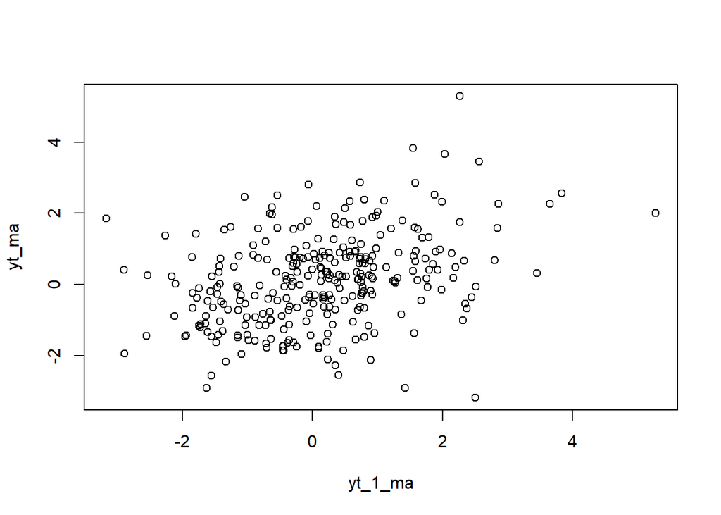

```r
plot(y=yt_ma,x=yt_1_ma)
```

Berdasarkan scatterplot tersebut, terlihat bahwa terdapat hubungan positif antara $Y_t$ dengan $Y_{t-1}$.

#### Nilai Korelasi antara $Y_t$ dengan $Y_{t-1}$

```r
cor(yt_ma,yt_1_ma)
```

```
## [1] 0.3513039
```

hubungan positif yang dilihat pada plot antara $Y_t$ dengan $Y_{t-1}$ juga didukung dengan nilai korelasi sebesar 0.3513039

```r
#Yt
yt_ma2 <- ma2[-c(1,2)]
yt_ma2
```

```
##   [1] -1.613619077 -0.458965633 -1.849768074  0.775675569  0.612865447
##   [6] -0.330563317  0.180278489 -0.622070865  1.964541612  0.977402389
##  [11]  1.925514489  0.412556489  0.271887865  0.254267147  0.164578663
##  [16] -0.353331613 -0.606860383 -0.243253432  0.574417961  0.923337453
##  [21]  0.803126768  0.583591439  0.797923360  2.378785234 -0.680728030
##  [26] -0.396569889  0.135612365  0.270921082  0.736793377  0.770788436
##  [31] -0.072929388  1.775433948 -0.065636272  0.777130675 -0.234732609
##  [36] -0.643055972 -1.010082314 -0.915229200  0.826159857  0.775772586
##  [41]  1.786295441  1.325233745  0.895928245 -0.175738682  1.614741417
##  [46]  0.123416308  0.478840147 -1.840961787 -0.656176535 -0.759094655
##  [51] -0.820843477 -1.147873740 -1.483364988 -1.626380971 -2.897030556
##  [56] -1.944689106 -1.422722659  0.021671271  0.863458942 -1.158085035
##  [61] -0.041446394 -0.814437202 -0.030114853 -1.422477786 -1.033221033
##  [66] -0.536084453  1.584980385  2.844429286  1.581831975  0.649960163
##  [71]  0.918134378  1.883268582  2.516067215 -0.062242917  2.804087998
```

[output cut: 45 more lines]

```r
#Yt-2
yt_2_ma <- ma2[-c(299,300)]
yt_2_ma
```

```
##   [1]  0.912665506  0.221474976 -1.613619077 -0.458965633 -1.849768074
##   [6]  0.775675569  0.612865447 -0.330563317  0.180278489 -0.622070865
##  [11]  1.964541612  0.977402389  1.925514489  0.412556489  0.271887865
##  [16]  0.254267147  0.164578663 -0.353331613 -0.606860383 -0.243253432
##  [21]  0.574417961  0.923337453  0.803126768  0.583591439  0.797923360
##  [26]  2.378785234 -0.680728030 -0.396569889  0.135612365  0.270921082
##  [31]  0.736793377  0.770788436 -0.072929388  1.775433948 -0.065636272
##  [36]  0.777130675 -0.234732609 -0.643055972 -1.010082314 -0.915229200
##  [41]  0.826159857  0.775772586  1.786295441  1.325233745  0.895928245
##  [46] -0.175738682  1.614741417  0.123416308  0.478840147 -1.840961787
##  [51] -0.656176535 -0.759094655 -0.820843477 -1.147873740 -1.483364988
##  [56] -1.626380971 -2.897030556 -1.944689106 -1.422722659  0.021671271
##  [61]  0.863458942 -1.158085035 -0.041446394 -0.814437202 -0.030114853
##  [66] -1.422477786 -1.033221033 -0.536084453  1.584980385  2.844429286
##  [71]  1.581831975  0.649960163  0.918134378  1.883268582  2.516067215
```

[output cut: 45 more lines]

#### Scatter Plot antara $Y_t$ dengan $Y_{t-2}$

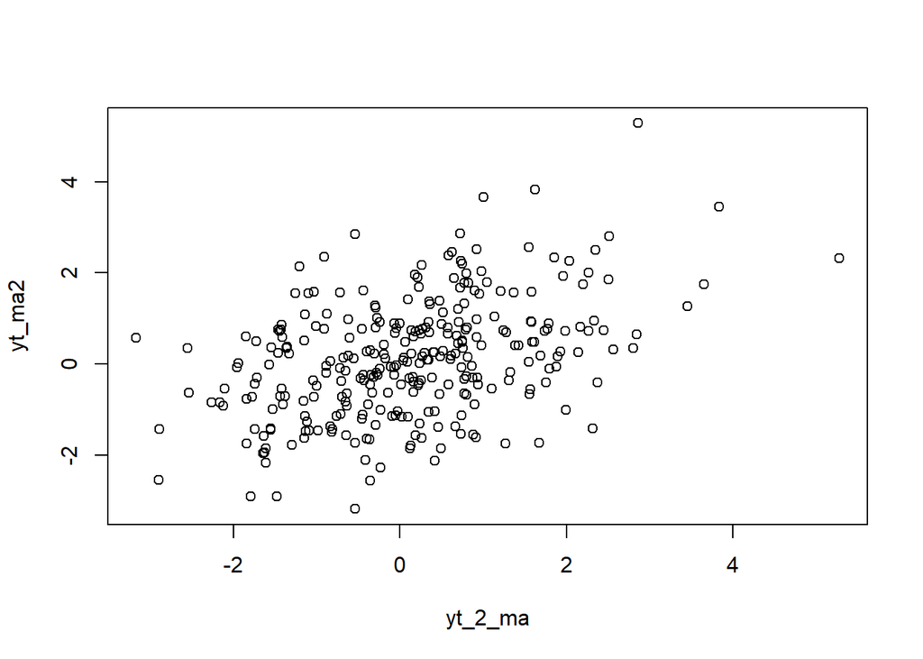

```r
plot(y=yt_ma2,x=yt_2_ma)
```

Berdasarkan scatterplot tersebut, terlihat bahwa terdapat hubungan positif antara $Y_t$ dengan $Y_{t-2}$

#### Nilai Korelasi antara $Y_t$ dengan $Y_{t-2}$

```r
cor(yt_ma2,yt_2_ma)
```

```
## [1] 0.428286
```

hubungan positif yang dilihat pada plot antara $Y_t$ dengan $Y_{t-2}$ juga didukung dengan nilai korelasi sebesar 0.428286

```r
#Yt
yt_ma3 <- ma2[-c(1,2,3)]
yt_ma3
```

```
##   [1] -0.458965633 -1.849768074  0.775675569  0.612865447 -0.330563317
##   [6]  0.180278489 -0.622070865  1.964541612  0.977402389  1.925514489
##  [11]  0.412556489  0.271887865  0.254267147  0.164578663 -0.353331613
##  [16] -0.606860383 -0.243253432  0.574417961  0.923337453  0.803126768
##  [21]  0.583591439  0.797923360  2.378785234 -0.680728030 -0.396569889
##  [26]  0.135612365  0.270921082  0.736793377  0.770788436 -0.072929388
##  [31]  1.775433948 -0.065636272  0.777130675 -0.234732609 -0.643055972
##  [36] -1.010082314 -0.915229200  0.826159857  0.775772586  1.786295441
##  [41]  1.325233745  0.895928245 -0.175738682  1.614741417  0.123416308
##  [46]  0.478840147 -1.840961787 -0.656176535 -0.759094655 -0.820843477
##  [51] -1.147873740 -1.483364988 -1.626380971 -2.897030556 -1.944689106
##  [56] -1.422722659  0.021671271  0.863458942 -1.158085035 -0.041446394
##  [61] -0.814437202 -0.030114853 -1.422477786 -1.033221033 -0.536084453
##  [66]  1.584980385  2.844429286  1.581831975  0.649960163  0.918134378
##  [71]  1.883268582  2.516067215 -0.062242917  2.804087998  0.681250473
```

[output cut: 45 more lines]

```r
#Yt-3
yt_3_ma <- ma2[-c(298,299,300)]
yt_3_ma
```

```
##   [1]  0.912665506  0.221474976 -1.613619077 -0.458965633 -1.849768074
##   [6]  0.775675569  0.612865447 -0.330563317  0.180278489 -0.622070865
##  [11]  1.964541612  0.977402389  1.925514489  0.412556489  0.271887865
##  [16]  0.254267147  0.164578663 -0.353331613 -0.606860383 -0.243253432
##  [21]  0.574417961  0.923337453  0.803126768  0.583591439  0.797923360
##  [26]  2.378785234 -0.680728030 -0.396569889  0.135612365  0.270921082
##  [31]  0.736793377  0.770788436 -0.072929388  1.775433948 -0.065636272
##  [36]  0.777130675 -0.234732609 -0.643055972 -1.010082314 -0.915229200
##  [41]  0.826159857  0.775772586  1.786295441  1.325233745  0.895928245
##  [46] -0.175738682  1.614741417  0.123416308  0.478840147 -1.840961787
##  [51] -0.656176535 -0.759094655 -0.820843477 -1.147873740 -1.483364988
##  [56] -1.626380971 -2.897030556 -1.944689106 -1.422722659  0.021671271
##  [61]  0.863458942 -1.158085035 -0.041446394 -0.814437202 -0.030114853
##  [66] -1.422477786 -1.033221033 -0.536084453  1.584980385  2.844429286
##  [71]  1.581831975  0.649960163  0.918134378  1.883268582  2.516067215
```

[output cut: 45 more lines]

#### Scatter Plot antara $Y_t$ dengan $Y_{t-3}$

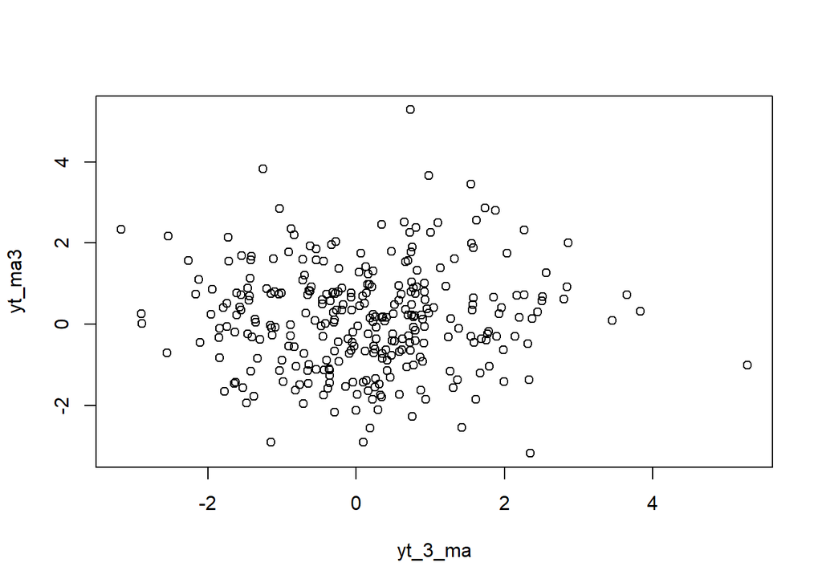

```r
plot(y=yt_ma3,x=yt_3_ma)
```

#### Nilai Korelasi antara $Y_t$ dengan $Y_{t-3}$

```r
cor(yt_ma3,yt_3_ma)
```

```
## [1] 0.0153008
```

## AR (2)

## Pembangkitan Proses AR

Akan dicoba membangkitkan proses AR, yaitu AR(2) dengan $\phi1 = 0.5$ dan $\phi2 = 0.2$ sebanyak 300 observasi dan $c=0$.

```r
set.seed(033)
```

### Membangkitkan AR dengan manual

```r
n<-length(wn)
n
```

```
## [1] 300
```

```r
ar <- c(1:n)
for (i in 3:n) {ar[i]<-wn[i]+0.5*ar[i-1]+0.2*ar[i-2]}
ar
```

```
##   [1]  1.0000000000  2.0000000000  2.2105390070  1.3470070587 -1.0410261724
##   [6]  0.2475351602 -0.8396819605  0.4082512429  0.7907671832 -0.6225117725
##  [11]  0.0142475117 -0.1466620801  1.8053634902  1.1179837961  1.6222182817
##  [16]  1.0196202350  0.6908836935  0.8700324722  0.6955270545 -0.0728951702
##  [21] -0.3397369287  0.1060560870  0.7087340372  0.8351521858  0.7444280608
##  [26]  0.7730494723  1.1287486099  2.7201511255 -0.2513724729 -0.4440469528
##  [31]  1.3105894251  0.7216860107  0.3479415539  1.1059837368  0.3995920905
##  [36]  1.8130165218  0.4977737689  0.7488677907  0.4774967453 -0.3383638411
##  [41] -0.7951154343 -0.6557550774  0.8483287863  0.6490089547  1.3369297977
##  [46]  1.5727992634  1.1342450684  0.2090403696  2.1668917365  0.9180464450
##  [51]  0.3528111928 -1.1407862523 -0.2319327416 -0.3098968525 -1.1966080466
##  [56] -1.4305839665 -1.5326945087 -1.9854323090 -3.4762497584 -2.6493216090
##  [61] -1.9307924871 -1.2007704411 -0.2943517875 -1.9989858638 -0.8704624887
##  [66] -0.7576324108 -0.7267224395 -1.9142775973 -1.4716601195 -0.6674653618
##  [71]  0.9979336932  2.2887715702  1.1808863414  0.6094134427  1.7323836934
```

[output cut: 45 more lines]

### Membangkitkan AR dengan fungsi

Selain menggunakan cara di atas, pembangkitan proses AR dapat dilakukan dengan fungsi `arima.sim()` sebagai berikut.

```r
ar_param <- c(0.5, 0.2)
ar1 <- arima.sim(model = list(order = c(2, 0, 0), ar = ar_param), n = 300)
ar1
```

```
## Time Series:
## Start = 1
## End = 300
## Frequency = 1
##   [1]  0.7703908031  1.1267217799  2.7186059767 -0.2525504133 -0.4449449528
##   [6]  1.3099048370  0.7211641167  0.3475436893  1.1056804257  0.3993608620
##  [11]  1.8128402453  0.4976393850  0.7487653434  0.4774186449 -0.3384233808
##  [16] -0.7951608242 -0.6557896803  0.8483024069  0.6489888444  1.3369144667
##  [21]  1.5727875758  1.1342361585  0.2090335771  2.1668865582  0.9180424974
##  [26]  0.3528081833 -1.1407885466 -0.2319344906 -0.3098981859 -1.1966090631
##  [31] -1.4305847414 -1.5326950994 -1.9854327593 -3.4762501018 -2.6493218708
##  [36] -1.9307926867 -1.2007705932 -0.2943519035 -1.9989859522 -0.8704625561
##  [41] -0.7576324622 -0.7267224787 -1.9142776271 -1.4716601422 -0.6674653792
##  [46]  0.9979336800  2.2887715601  1.1808863337  0.6094134369  1.7323836889
##  [51]  2.6580136578  2.8086753091  0.4184572969  3.5021298988  2.3340302594
```

[output cut: 49 more lines]

## Karakteristik AR(2)

### Plot Time Series

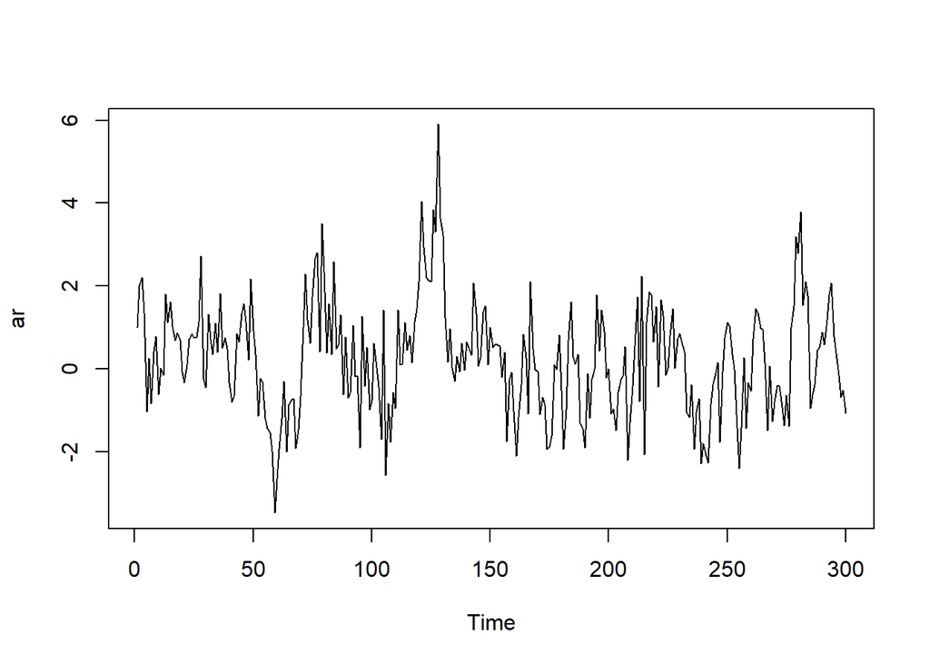

```r
ts.plot(ar)
```

Berdasarkan plot time series tersebut terlihat bahwa data cenderung stasioner pada rataan

### Plot ACF

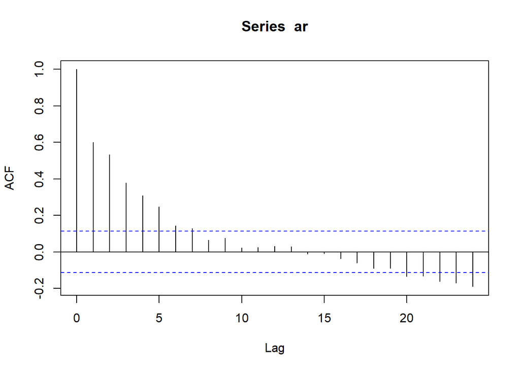

```r
acf(ar)
```

Berdasarkan plot ACF tersebut terlihat bahwa plot ACF cenderung *tails off* dan cenderung membentuk pola grafik sinus

### Plot PACF

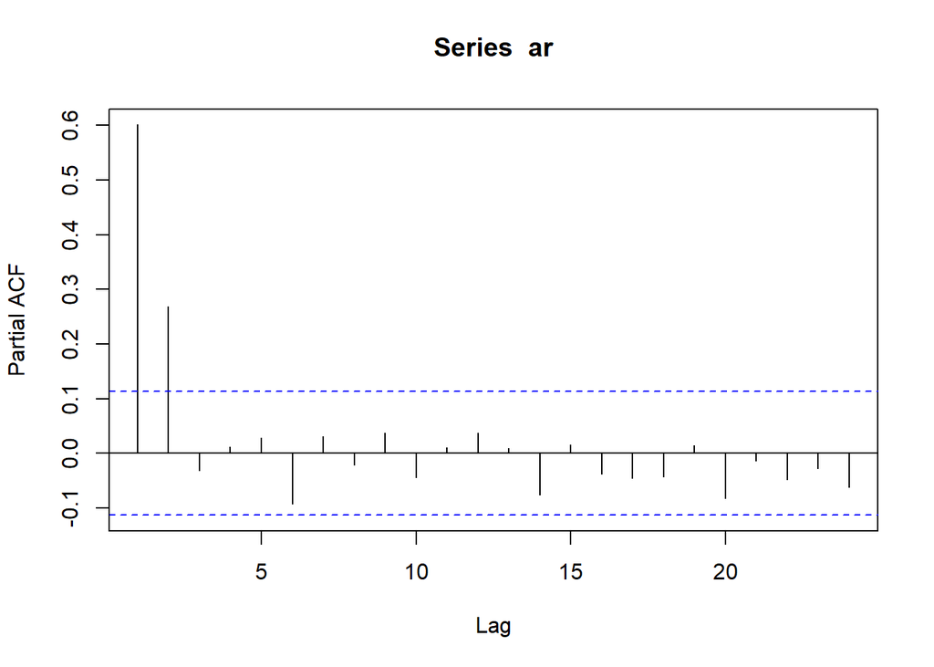

```r
pacf(ar)
```

Berdasarkan plot PACF tersebut, terlihat bahwa plot PACF *cuts off* pada lag kedua.

### Plot EACF

```r
TSA::eacf(ar)
```

```
## AR/MA
##   0 1 2 3 4 5 6 7 8 9 10 11 12 13
## 0 x x x x x x x o o o o  o  o  o
## 1 x x o o o o o o o o o  o  o  o
## 2 o o o o o o o o o o o  o  o  o
## 3 x o o o o o o o o o o  o  o  o
## 4 x o o x o o o o o o o  o  o  o
## 5 x x x x o o o o o o o  o  o  o
## 6 x x x x o o o o o o o  o  o  o
## 7 x o o x o x o o o o o  o  o  o
```

Berdasarkan pola segitiga nol pada plot EACF, terlihat bahwa segitiga nol berada pada ordo AR(1) dan ordo MA(2)

### Scatterplot Antar Lag

```r
#Yt
yt_ar <- ar[-1]
yt_ar
```

```
##   [1]  2.0000000000  2.2105390070  1.3470070587 -1.0410261724  0.2475351602
##   [6] -0.8396819605  0.4082512429  0.7907671832 -0.6225117725  0.0142475117
##  [11] -0.1466620801  1.8053634902  1.1179837961  1.6222182817  1.0196202350
##  [16]  0.6908836935  0.8700324722  0.6955270545 -0.0728951702 -0.3397369287
##  [21]  0.1060560870  0.7087340372  0.8351521858  0.7444280608  0.7730494723
##  [26]  1.1287486099  2.7201511255 -0.2513724729 -0.4440469528  1.3105894251
##  [31]  0.7216860107  0.3479415539  1.1059837368  0.3995920905  1.8130165218
##  [36]  0.4977737689  0.7488677907  0.4774967453 -0.3383638411 -0.7951154343
##  [41] -0.6557550774  0.8483287863  0.6490089547  1.3369297977  1.5727992634
##  [46]  1.1342450684  0.2090403696  2.1668917365  0.9180464450  0.3528111928
##  [51] -1.1407862523 -0.2319327416 -0.3098968525 -1.1966080466 -1.4305839665
##  [56] -1.5326945087 -1.9854323090 -3.4762497584 -2.6493216090 -1.9307924871
##  [61] -1.2007704411 -0.2943517875 -1.9989858638 -0.8704624887 -0.7576324108
##  [66] -0.7267224395 -1.9142775973 -1.4716601195 -0.6674653618  0.9979336932
##  [71]  2.2887715702  1.1808863414  0.6094134427  1.7323836934  2.6580136612
```

[output cut: 45 more lines]

```r
#Yt-1
yt_1_ar <- ar[-300]
yt_1_ar
```

```
##   [1]  1.0000000000  2.0000000000  2.2105390070  1.3470070587 -1.0410261724
##   [6]  0.2475351602 -0.8396819605  0.4082512429  0.7907671832 -0.6225117725
##  [11]  0.0142475117 -0.1466620801  1.8053634902  1.1179837961  1.6222182817
##  [16]  1.0196202350  0.6908836935  0.8700324722  0.6955270545 -0.0728951702
##  [21] -0.3397369287  0.1060560870  0.7087340372  0.8351521858  0.7444280608
##  [26]  0.7730494723  1.1287486099  2.7201511255 -0.2513724729 -0.4440469528
##  [31]  1.3105894251  0.7216860107  0.3479415539  1.1059837368  0.3995920905
##  [36]  1.8130165218  0.4977737689  0.7488677907  0.4774967453 -0.3383638411
##  [41] -0.7951154343 -0.6557550774  0.8483287863  0.6490089547  1.3369297977
##  [46]  1.5727992634  1.1342450684  0.2090403696  2.1668917365  0.9180464450
##  [51]  0.3528111928 -1.1407862523 -0.2319327416 -0.3098968525 -1.1966080466
##  [56] -1.4305839665 -1.5326945087 -1.9854323090 -3.4762497584 -2.6493216090
##  [61] -1.9307924871 -1.2007704411 -0.2943517875 -1.9989858638 -0.8704624887
##  [66] -0.7576324108 -0.7267224395 -1.9142775973 -1.4716601195 -0.6674653618
##  [71]  0.9979336932  2.2887715702  1.1808863414  0.6094134427  1.7323836934
```

[output cut: 45 more lines]

```r
#Yt
yt_ar2 <- ar[-c(1,2)]
yt_ar2
```

```
##   [1]  2.2105390070  1.3470070587 -1.0410261724  0.2475351602 -0.8396819605
##   [6]  0.4082512429  0.7907671832 -0.6225117725  0.0142475117 -0.1466620801
##  [11]  1.8053634902  1.1179837961  1.6222182817  1.0196202350  0.6908836935
##  [16]  0.8700324722  0.6955270545 -0.0728951702 -0.3397369287  0.1060560870
##  [21]  0.7087340372  0.8351521858  0.7444280608  0.7730494723  1.1287486099
##  [26]  2.7201511255 -0.2513724729 -0.4440469528  1.3105894251  0.7216860107
##  [31]  0.3479415539  1.1059837368  0.3995920905  1.8130165218  0.4977737689
##  [36]  0.7488677907  0.4774967453 -0.3383638411 -0.7951154343 -0.6557550774
##  [41]  0.8483287863  0.6490089547  1.3369297977  1.5727992634  1.1342450684
##  [46]  0.2090403696  2.1668917365  0.9180464450  0.3528111928 -1.1407862523
##  [51] -0.2319327416 -0.3098968525 -1.1966080466 -1.4305839665 -1.5326945087
##  [56] -1.9854323090 -3.4762497584 -2.6493216090 -1.9307924871 -1.2007704411
##  [61] -0.2943517875 -1.9989858638 -0.8704624887 -0.7576324108 -0.7267224395
##  [66] -1.9142775973 -1.4716601195 -0.6674653618  0.9979336932  2.2887715702
##  [71]  1.1808863414  0.6094134427  1.7323836934  2.6580136612  2.8086753117
```

[output cut: 45 more lines]

```r
#Yt-1
yt_2_ar <- ar[-c(299,300)]
yt_2_ar
```

```
##   [1]  1.0000000000  2.0000000000  2.2105390070  1.3470070587 -1.0410261724
##   [6]  0.2475351602 -0.8396819605  0.4082512429  0.7907671832 -0.6225117725
##  [11]  0.0142475117 -0.1466620801  1.8053634902  1.1179837961  1.6222182817
##  [16]  1.0196202350  0.6908836935  0.8700324722  0.6955270545 -0.0728951702
##  [21] -0.3397369287  0.1060560870  0.7087340372  0.8351521858  0.7444280608
##  [26]  0.7730494723  1.1287486099  2.7201511255 -0.2513724729 -0.4440469528
##  [31]  1.3105894251  0.7216860107  0.3479415539  1.1059837368  0.3995920905
##  [36]  1.8130165218  0.4977737689  0.7488677907  0.4774967453 -0.3383638411
##  [41] -0.7951154343 -0.6557550774  0.8483287863  0.6490089547  1.3369297977
##  [46]  1.5727992634  1.1342450684  0.2090403696  2.1668917365  0.9180464450
##  [51]  0.3528111928 -1.1407862523 -0.2319327416 -0.3098968525 -1.1966080466
##  [56] -1.4305839665 -1.5326945087 -1.9854323090 -3.4762497584 -2.6493216090
##  [61] -1.9307924871 -1.2007704411 -0.2943517875 -1.9989858638 -0.8704624887
##  [66] -0.7576324108 -0.7267224395 -1.9142775973 -1.4716601195 -0.6674653618
##  [71]  0.9979336932  2.2887715702  1.1808863414  0.6094134427  1.7323836934
```

[output cut: 45 more lines]

```r
#Yt
yt_ar3 <- ar[-c(1,2,3)]
yt_ar3
```

```
##   [1]  1.3470070587 -1.0410261724  0.2475351602 -0.8396819605  0.4082512429
##   [6]  0.7907671832 -0.6225117725  0.0142475117 -0.1466620801  1.8053634902
##  [11]  1.1179837961  1.6222182817  1.0196202350  0.6908836935  0.8700324722
##  [16]  0.6955270545 -0.0728951702 -0.3397369287  0.1060560870  0.7087340372
##  [21]  0.8351521858  0.7444280608  0.7730494723  1.1287486099  2.7201511255
##  [26] -0.2513724729 -0.4440469528  1.3105894251  0.7216860107  0.3479415539
##  [31]  1.1059837368  0.3995920905  1.8130165218  0.4977737689  0.7488677907
##  [36]  0.4774967453 -0.3383638411 -0.7951154343 -0.6557550774  0.8483287863
##  [41]  0.6490089547  1.3369297977  1.5727992634  1.1342450684  0.2090403696
##  [46]  2.1668917365  0.9180464450  0.3528111928 -1.1407862523 -0.2319327416
##  [51] -0.3098968525 -1.1966080466 -1.4305839665 -1.5326945087 -1.9854323090
##  [56] -3.4762497584 -2.6493216090 -1.9307924871 -1.2007704411 -0.2943517875
##  [61] -1.9989858638 -0.8704624887 -0.7576324108 -0.7267224395 -1.9142775973
##  [66] -1.4716601195 -0.6674653618  0.9979336932  2.2887715702  1.1808863414
##  [71]  0.6094134427  1.7323836934  2.6580136612  2.8086753117  0.4184572989
```

[output cut: 45 more lines]

```r
#Yt-1
yt_3_ar <- ar[-c(298,299,300)]
yt_3_ar
```

```
##   [1]  1.0000000000  2.0000000000  2.2105390070  1.3470070587 -1.0410261724
##   [6]  0.2475351602 -0.8396819605  0.4082512429  0.7907671832 -0.6225117725
##  [11]  0.0142475117 -0.1466620801  1.8053634902  1.1179837961  1.6222182817
##  [16]  1.0196202350  0.6908836935  0.8700324722  0.6955270545 -0.0728951702
##  [21] -0.3397369287  0.1060560870  0.7087340372  0.8351521858  0.7444280608
##  [26]  0.7730494723  1.1287486099  2.7201511255 -0.2513724729 -0.4440469528
##  [31]  1.3105894251  0.7216860107  0.3479415539  1.1059837368  0.3995920905
##  [36]  1.8130165218  0.4977737689  0.7488677907  0.4774967453 -0.3383638411
##  [41] -0.7951154343 -0.6557550774  0.8483287863  0.6490089547  1.3369297977
##  [46]  1.5727992634  1.1342450684  0.2090403696  2.1668917365  0.9180464450
##  [51]  0.3528111928 -1.1407862523 -0.2319327416 -0.3098968525 -1.1966080466
##  [56] -1.4305839665 -1.5326945087 -1.9854323090 -3.4762497584 -2.6493216090
##  [61] -1.9307924871 -1.2007704411 -0.2943517875 -1.9989858638 -0.8704624887
##  [66] -0.7576324108 -0.7267224395 -1.9142775973 -1.4716601195 -0.6674653618
##  [71]  0.9979336932  2.2887715702  1.1808863414  0.6094134427  1.7323836934
```

[output cut: 45 more lines]

#### Scatter Plot antara $Y_t$ dengan $Y_{t-1}$

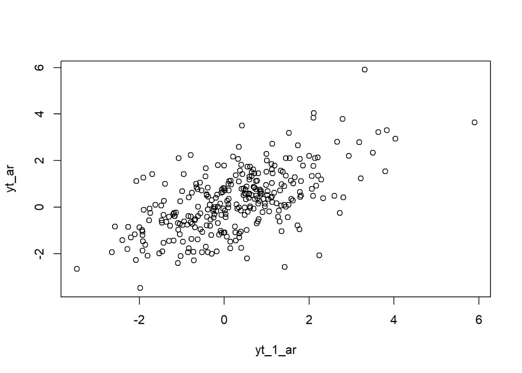

```r
plot(y=yt_ar,x=yt_1_ar)
```

Berdasarkan scatterplot tersebut, terlihat bahwa terdapat hubungan positif antara $Y_t$ dengan $Y_{t-1}$

#### Nilai Korelasi antara $Y_t$ dengan $Y_{t-1}$

```r
cor(yt_ar,yt_1_ar)
```

```
## [1] 0.6024695
```

hubungan positif yang dilihat pada plot antara $Y_t$ dengan $Y_{t-1}$ juga didukung dengan nilai korelasi sebesar 0.6024695

#### Scatter Plot antara $Y_t$ dengan $Y_{t-2}$

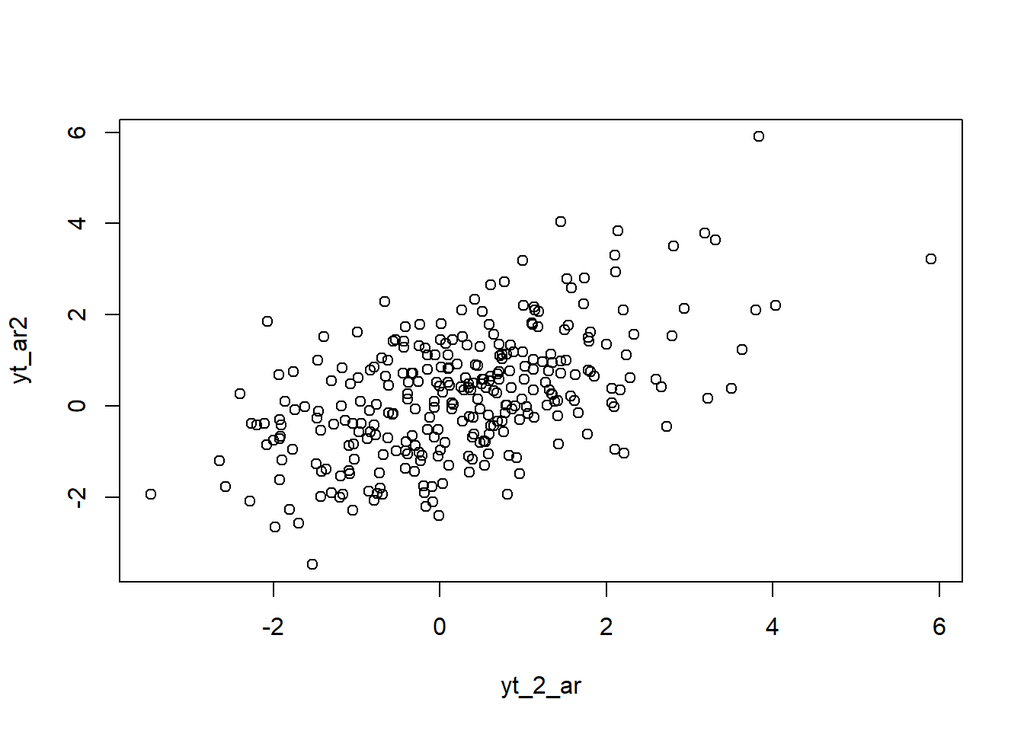

```r
plot(y=yt_ar2,x=yt_2_ar)
```

Berdasarkan scatterplot tersebut, terlihat bahwa terdapat hubungan positif antara $Y_t$ dengan $Y_{t-2}$

#### Nilai Korelasi antara $Y_t$ dengan $Y_{t-2}$

```r
cor(yt_ar2,yt_2_ar)
```

```
## [1] 0.5361497
```

hubungan positif yang dilihat pada plot antara $Y_t$ dengan $Y_{t-2}$ juga didukung dengan nilai korelasi sebesar 0.5361497

#### Scatter Plot antara $Y_t$ dengan $Y_{t-3}$

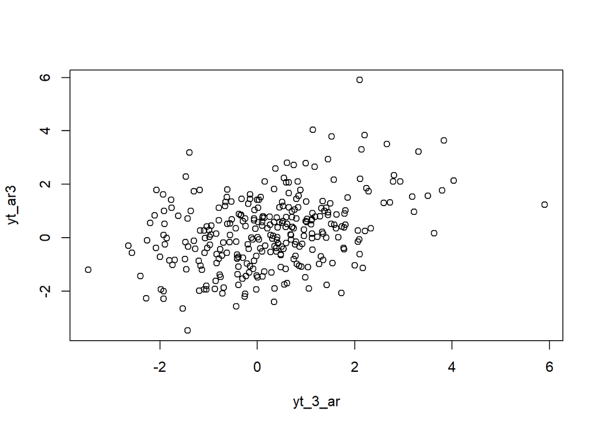

```r
plot(y=yt_ar3,x=yt_3_ar)
```

Berdasarkan scatterplot tersebut, terlihat bahwa terdapat hubungan positif antara $Y_t$ dengan $Y_{t-3}$

#### Nilai Korelasi antara $Y_t$ dengan $Y_{t-3}$

```r
cor(yt_ar3,yt_3_ar)
```

```
## [1] 0.3813409
```

hubungan positif yang dilihat pada plot antara $Y_t$ dengan $Y_{t-3}$ juga didukung dengan nilai korelasi sebesar 0.3813409

## ARMA (2,2)

Setelah mengetahui cara membangkitkan data berpola AR, MA, dan ARMA sederhana, bagaimana cara melakukan pembangkitan data berpola tersebut yang lebih kompleks? Apakah dapat dibuat suatu fungsi yang fleksibel yang memungkinan pembangkitan dengan berapapun jumlah koefisien?

Pertama, lihat kembali bentuk umum data berpola ARMA.

$$y_{t} = c + \sum_{i=1}^p \phi_{i}y_{t-i} + \sum_{j=1}^q e_{t-j}+ e_{t}$$

## Pembangkitan Model Arma

### Membangkitkan Model Arma Manual

```r
#Membangkitkan Model Arma (2,2) dengan teta 1 = 0.4, teta 2 = 0.6, phi 1 = 0.5, phi 2 = 0.2 sebanyak 300
set.seed(033)
n = length(wn)
phi1 = 0.5
phi2 = 0.2
theta1 = 0.4
theta2 = 0.6

y.arma = c(1:n)
for (i in 5:n) {
  y.arma[i] = phi1 * y.arma[i-1] + phi2 * y.arma[i-2] + theta1 * wn[i-1] + theta2 * wn[i-2] + wn[i]
}
```

### Membangkitkan ARMA dengan fungsi

Pembangkitan ARMA(p,q) juga dapat dilakukan dengan fungsi `arima.sim` sebagai berikut.

```r
arma22 <- arima.sim(list(order=c(2,0,2), ar = c(0.5,0.2), ma = c(0.4,0.6)), n=300)
arma22
```

```
## Time Series:
## Start = 1
## End = 300
## Frequency = 1
##   [1]  3.63165679  1.51102234  1.08527264  0.98045315  0.97820219  1.42198510
##   [7]  1.67742142  1.05017834  2.63600741  1.46240310  2.03553371  1.07551486
##  [13]  0.30180820 -0.64407524 -1.17690518  0.10889222  0.59483766  2.10549271
##  [19]  2.49694763  2.56550060  1.60640115  2.93104211  1.91021759  2.02015737
##  [25] -0.44883959 -0.47656485 -1.08714500 -1.45972895 -2.09516721 -2.82289439
##  [31] -3.45686161 -5.19004024 -5.23108155 -5.07627148 -3.56268078 -1.93313574
##  [37] -2.83718906 -1.84666807 -2.30520905 -1.55205299 -2.65954609 -2.67340468
##  [43] -2.40469601 -0.15204856  2.28746581  2.69515517  2.45503091  2.68468086
##  [49]  3.71661520  4.91131099  3.13673562  5.35471800  3.98595660  3.41040404
##  [55]  3.12692588  1.20236834  3.67822965  1.72470966  2.33858406  1.82427835
##  [61]  0.24829705  1.29051505 -0.77365972 -0.39323256  0.40517274 -0.11056560
```

[output cut: 39 more lines]

## Karakteristik ARMA(2,2)

### Plot Time Series

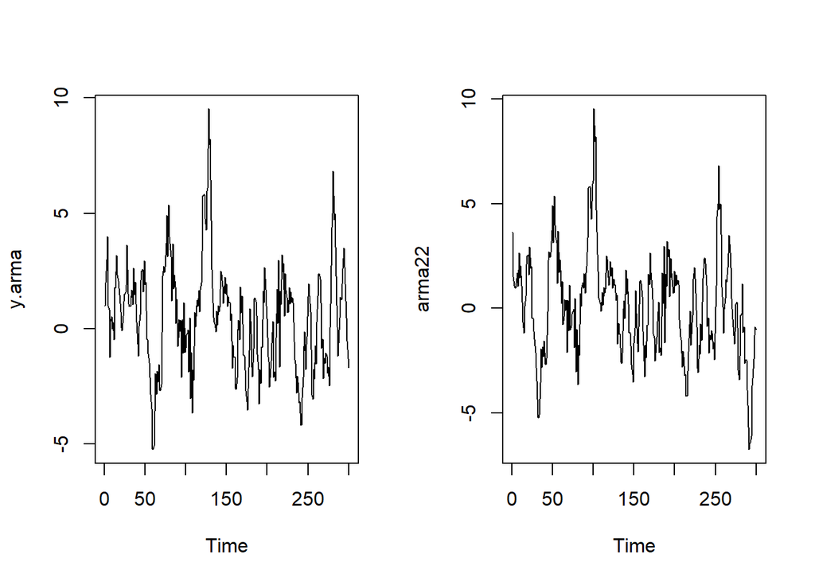

```r
par(mfrow = c(1, 2))
ts.plot(y.arma)
ts.plot(arma22)
```

```r
par(mfrow = c(1, 1))
```

Berdasarkan plot time series tersebut, terlihat bahwa model ARMA(2,2) cenderung stasioner dalam rataan

### Plot ACF

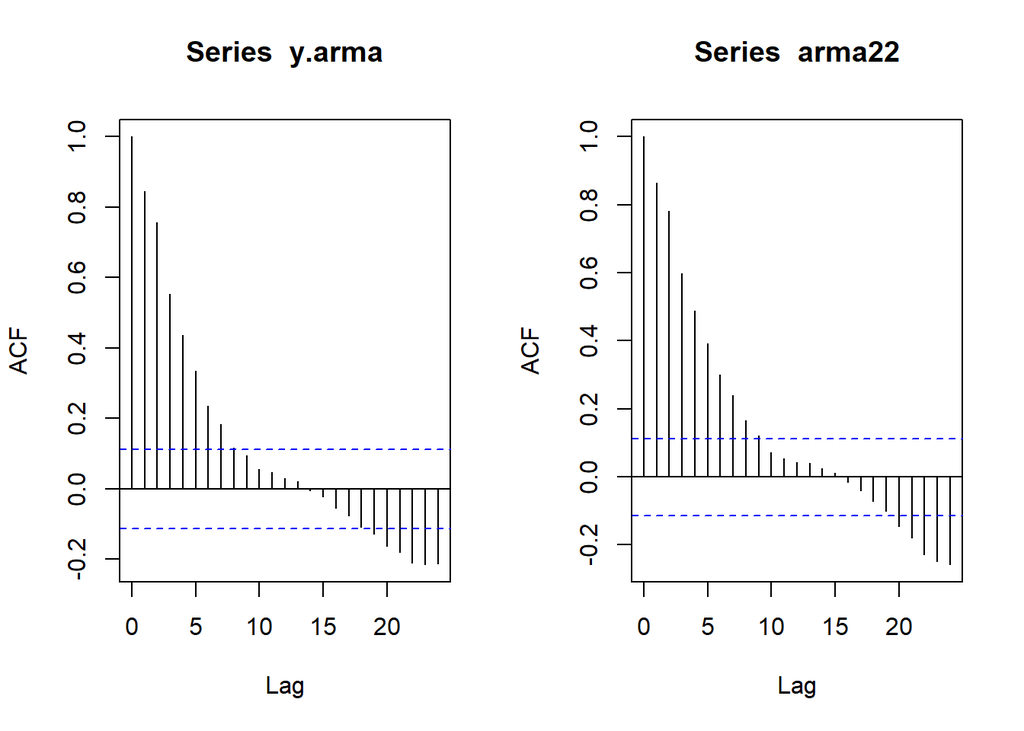

```r
par(mfrow = c(1, 2))
acf(y.arma)
acf(arma22)
```

```r
par(mfrow = c(1, 1))
```

Berdasarkan plot ACF tersebut, terlihat bahwa model ARMA(2,2) hasil simulasi memiliki plot ACF yang *tails off*

### Plot PACF

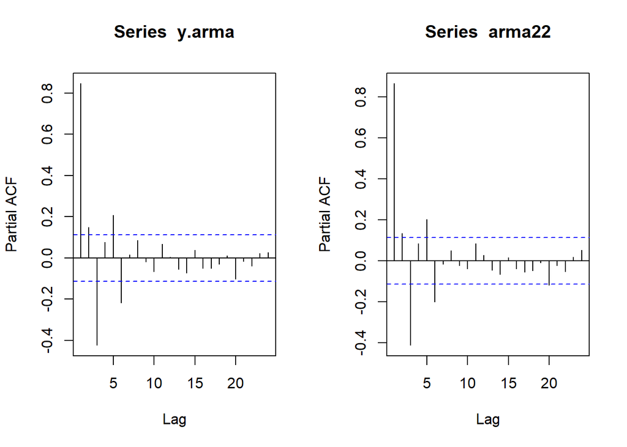

```r
par(mfrow = c(1, 2))
pacf(y.arma)
pacf(arma22)
```

```r
par(mfrow = c(1, 1))
```

Berdasarkan plot PACF tersebut, terlihat bahwa model ARMA(2,2) hasil simulasi memiliki beberapa autokorelasi pada datanya.

### Plot EACF

```r
TSA::eacf(y.arma)
```

```
## AR/MA
##   0 1 2 3 4 5 6 7 8 9 10 11 12 13
## 0 x x x x x x x o o o o  o  o  o
## 1 x x x o o o o o o o o  o  o  o
## 2 x x o o o o o o o o o  o  o  o
## 3 x x o x x o o o o o o  o  o  o
## 4 x x x x o o o o o o o  o  o  o
## 5 x x x x x o o o o o o  o  o  o
## 6 o x x o o o o o o o o  o  o  o
## 7 x x x o o o o o o o o  o  o  o
```

```r
TSA::eacf(arma22)
```

```
## AR/MA
##   0 1 2 3 4 5 6 7 8 9 10 11 12 13
## 0 x x x x x x x x x o o  o  o  o
## 1 x x x o o o o o o o o  o  o  o
## 2 x x o o o o o o o o o  o  o  o
## 3 x x o o o o o o o o o  o  o  o
## 4 x x o x o o o o o o o  o  o  o
## 5 x x o x o o o o o o o  o  o  o
## 6 o x o x x o o o o o o  o  o  o
## 7 o x o o x o x o o o o  o  o  o
```

Berdasarkan pola segitiga nol pada plot EACF, terlihat bahwa segitiga nol berada pada ordo AR(1) dan ordo MA(3)

### Scatterplot Antar Lag

```r
#Yt
yt_arma <- arma22[-1]
yt_arma
```

```
##   [1]  1.51102234  1.08527264  0.98045315  0.97820219  1.42198510  1.67742142
##   [7]  1.05017834  2.63600741  1.46240310  2.03553371  1.07551486  0.30180820
##  [13] -0.64407524 -1.17690518  0.10889222  0.59483766  2.10549271  2.49694763
##  [19]  2.56550060  1.60640115  2.93104211  1.91021759  2.02015737 -0.44883959
##  [25] -0.47656485 -1.08714500 -1.45972895 -2.09516721 -2.82289439 -3.45686161
##  [31] -5.19004024 -5.23108155 -5.07627148 -3.56268078 -1.93313574 -2.83718906
##  [37] -1.84666807 -2.30520905 -1.55205299 -2.65954609 -2.67340468 -2.40469601
##  [43] -0.15204856  2.28746581  2.69515517  2.45503091  2.68468086  3.71661520
##  [49]  4.91131099  3.13673562  5.35471800  3.98595660  3.41040404  3.12692588
##  [55]  1.20236834  3.67822965  1.72470966  2.33858406  1.82427835  0.24829705
##  [61]  1.29051505 -0.77365972 -0.39323256  0.40517274 -0.11056560  0.38079705
##  [67] -2.09486140  0.39866518 -1.05404545  1.11869713 -1.02154799 -0.84498062
##  [73] -0.28340819 -0.18514610 -0.05738532 -1.85958740  0.48193251 -3.03064598
##  [79] -1.01577544 -3.65280086 -1.77218263 -2.23881629  0.69910008  0.08915066
##  [85]  0.99807470  1.22438916  0.96796513  1.65475316  0.74336862  1.68056524
```

[output cut: 35 more lines]

```r
#Yt-1
yt_1_arma <- arma22[-300]
yt_1_arma
```

```
##   [1]  3.63165679  1.51102234  1.08527264  0.98045315  0.97820219  1.42198510
##   [7]  1.67742142  1.05017834  2.63600741  1.46240310  2.03553371  1.07551486
##  [13]  0.30180820 -0.64407524 -1.17690518  0.10889222  0.59483766  2.10549271
##  [19]  2.49694763  2.56550060  1.60640115  2.93104211  1.91021759  2.02015737
##  [25] -0.44883959 -0.47656485 -1.08714500 -1.45972895 -2.09516721 -2.82289439
##  [31] -3.45686161 -5.19004024 -5.23108155 -5.07627148 -3.56268078 -1.93313574
##  [37] -2.83718906 -1.84666807 -2.30520905 -1.55205299 -2.65954609 -2.67340468
##  [43] -2.40469601 -0.15204856  2.28746581  2.69515517  2.45503091  2.68468086
##  [49]  3.71661520  4.91131099  3.13673562  5.35471800  3.98595660  3.41040404
##  [55]  3.12692588  1.20236834  3.67822965  1.72470966  2.33858406  1.82427835
##  [61]  0.24829705  1.29051505 -0.77365972 -0.39323256  0.40517274 -0.11056560
##  [67]  0.38079705 -2.09486140  0.39866518 -1.05404545  1.11869713 -1.02154799
##  [73] -0.84498062 -0.28340819 -0.18514610 -0.05738532 -1.85958740  0.48193251
##  [79] -3.03064598 -1.01577544 -3.65280086 -1.77218263 -2.23881629  0.69910008
##  [85]  0.08915066  0.99807470  1.22438916  0.96796513  1.65475316  0.74336862
```

[output cut: 35 more lines]

#### Scatter Plot antara $Y_t$ dengan $Y_{t-1}$

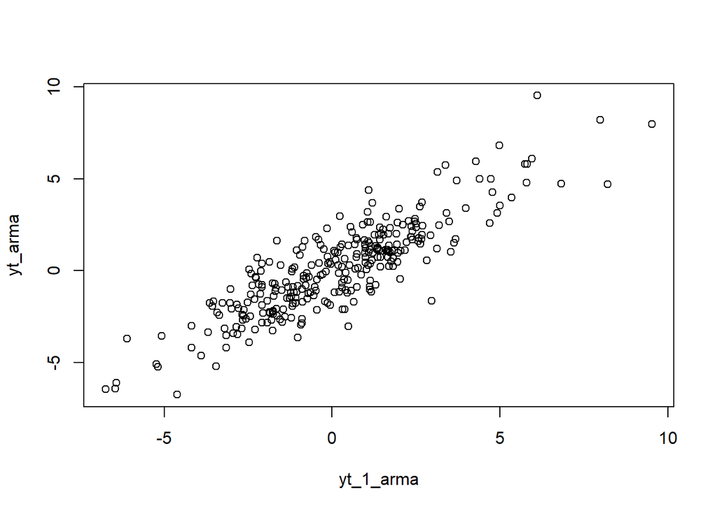

```r
plot(y=yt_arma,x=yt_1_arma)
```

Berdasarkan scatterplot tersebut, terlihat bahwa terdapat hubungan positif antara $Y_t$ dengan $Y_{t-1}$. Hal ini sesuai dengan teori yang ada

#### Nilai Korelasi antara $Y_t$ dengan $Y_{t-1}$

```r
cor(yt_arma,yt_1_arma)
```

```
## [1] 0.8676951
```

hubungan positif yang dilihat pada plot antara $Y_t$ dengan $Y_{t-1}$ juga didukung dengan nilai korelasi sebesar 0.8676951

```r
#Yt
yt_arma2 <- arma22[-c(1,2)]
yt_arma2
```

```
##   [1]  1.08527264  0.98045315  0.97820219  1.42198510  1.67742142  1.05017834
##   [7]  2.63600741  1.46240310  2.03553371  1.07551486  0.30180820 -0.64407524
##  [13] -1.17690518  0.10889222  0.59483766  2.10549271  2.49694763  2.56550060
##  [19]  1.60640115  2.93104211  1.91021759  2.02015737 -0.44883959 -0.47656485
##  [25] -1.08714500 -1.45972895 -2.09516721 -2.82289439 -3.45686161 -5.19004024
##  [31] -5.23108155 -5.07627148 -3.56268078 -1.93313574 -2.83718906 -1.84666807
##  [37] -2.30520905 -1.55205299 -2.65954609 -2.67340468 -2.40469601 -0.15204856
##  [43]  2.28746581  2.69515517  2.45503091  2.68468086  3.71661520  4.91131099
##  [49]  3.13673562  5.35471800  3.98595660  3.41040404  3.12692588  1.20236834
##  [55]  3.67822965  1.72470966  2.33858406  1.82427835  0.24829705  1.29051505
##  [61] -0.77365972 -0.39323256  0.40517274 -0.11056560  0.38079705 -2.09486140
##  [67]  0.39866518 -1.05404545  1.11869713 -1.02154799 -0.84498062 -0.28340819
##  [73] -0.18514610 -0.05738532 -1.85958740  0.48193251 -3.03064598 -1.01577544
##  [79] -3.65280086 -1.77218263 -2.23881629  0.69910008  0.08915066  0.99807470
##  [85]  1.22438916  0.96796513  1.65475316  0.74336862  1.68056524  1.99446181
```

[output cut: 35 more lines]

```r
#Yt-2
yt_2_arma <- arma22[-c(299,300)]
yt_2_arma
```

```
##   [1]  3.63165679  1.51102234  1.08527264  0.98045315  0.97820219  1.42198510
##   [7]  1.67742142  1.05017834  2.63600741  1.46240310  2.03553371  1.07551486
##  [13]  0.30180820 -0.64407524 -1.17690518  0.10889222  0.59483766  2.10549271
##  [19]  2.49694763  2.56550060  1.60640115  2.93104211  1.91021759  2.02015737
##  [25] -0.44883959 -0.47656485 -1.08714500 -1.45972895 -2.09516721 -2.82289439
##  [31] -3.45686161 -5.19004024 -5.23108155 -5.07627148 -3.56268078 -1.93313574
##  [37] -2.83718906 -1.84666807 -2.30520905 -1.55205299 -2.65954609 -2.67340468
##  [43] -2.40469601 -0.15204856  2.28746581  2.69515517  2.45503091  2.68468086
##  [49]  3.71661520  4.91131099  3.13673562  5.35471800  3.98595660  3.41040404
##  [55]  3.12692588  1.20236834  3.67822965  1.72470966  2.33858406  1.82427835
##  [61]  0.24829705  1.29051505 -0.77365972 -0.39323256  0.40517274 -0.11056560
##  [67]  0.38079705 -2.09486140  0.39866518 -1.05404545  1.11869713 -1.02154799
##  [73] -0.84498062 -0.28340819 -0.18514610 -0.05738532 -1.85958740  0.48193251
##  [79] -3.03064598 -1.01577544 -3.65280086 -1.77218263 -2.23881629  0.69910008
##  [85]  0.08915066  0.99807470  1.22438916  0.96796513  1.65475316  0.74336862
```

[output cut: 35 more lines]

#### Scatter Plot antara $Y_t$ dengan $Y_{t-2}$

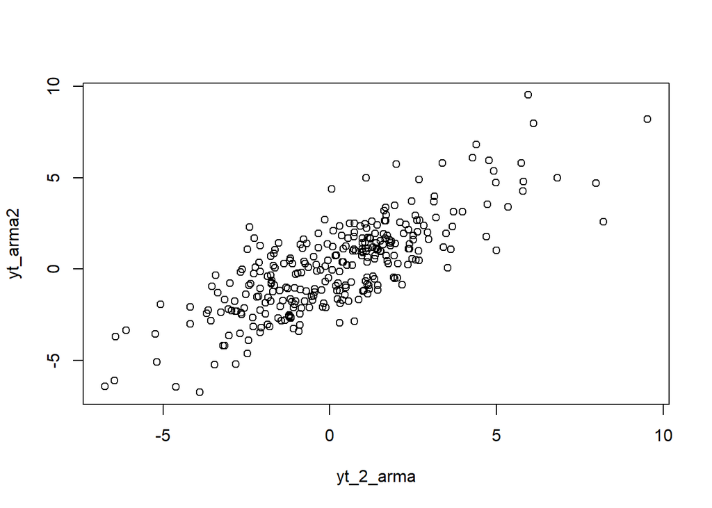

```r
plot(y=yt_arma2,x=yt_2_arma)
```

#### Nilai Korelasi antara $Y_t$ dengan $Y_{t-2}$

```r
cor(yt_arma2,yt_2_arma)
```

```
## [1] 0.7849538
```

hubungan positif yang dilihat pada plot antara $Y_t$ dengan $Y_{t-2}$ juga didukung dengan nilai korelasi sebesar 0.7849538

```r
#Yt
yt_arma3 <- arma22[-c(1,2,3)]
yt_arma3
```

```
##   [1]  0.98045315  0.97820219  1.42198510  1.67742142  1.05017834  2.63600741
##   [7]  1.46240310  2.03553371  1.07551486  0.30180820 -0.64407524 -1.17690518
##  [13]  0.10889222  0.59483766  2.10549271  2.49694763  2.56550060  1.60640115
##  [19]  2.93104211  1.91021759  2.02015737 -0.44883959 -0.47656485 -1.08714500
##  [25] -1.45972895 -2.09516721 -2.82289439 -3.45686161 -5.19004024 -5.23108155
##  [31] -5.07627148 -3.56268078 -1.93313574 -2.83718906 -1.84666807 -2.30520905
##  [37] -1.55205299 -2.65954609 -2.67340468 -2.40469601 -0.15204856  2.28746581
##  [43]  2.69515517  2.45503091  2.68468086  3.71661520  4.91131099  3.13673562
##  [49]  5.35471800  3.98595660  3.41040404  3.12692588  1.20236834  3.67822965
##  [55]  1.72470966  2.33858406  1.82427835  0.24829705  1.29051505 -0.77365972
##  [61] -0.39323256  0.40517274 -0.11056560  0.38079705 -2.09486140  0.39866518
##  [67] -1.05404545  1.11869713 -1.02154799 -0.84498062 -0.28340819 -0.18514610
##  [73] -0.05738532 -1.85958740  0.48193251 -3.03064598 -1.01577544 -3.65280086
##  [79] -1.77218263 -2.23881629  0.69910008  0.08915066  0.99807470  1.22438916
##  [85]  0.96796513  1.65475316  0.74336862  1.68056524  1.99446181  3.37254266
```

[output cut: 35 more lines]

```r
#Yt-3
yt_3_arma <- arma22[-c(298,299,300)]
yt_3_arma
```

```
##   [1]  3.63165679  1.51102234  1.08527264  0.98045315  0.97820219  1.42198510
##   [7]  1.67742142  1.05017834  2.63600741  1.46240310  2.03553371  1.07551486
##  [13]  0.30180820 -0.64407524 -1.17690518  0.10889222  0.59483766  2.10549271
##  [19]  2.49694763  2.56550060  1.60640115  2.93104211  1.91021759  2.02015737
##  [25] -0.44883959 -0.47656485 -1.08714500 -1.45972895 -2.09516721 -2.82289439
##  [31] -3.45686161 -5.19004024 -5.23108155 -5.07627148 -3.56268078 -1.93313574
##  [37] -2.83718906 -1.84666807 -2.30520905 -1.55205299 -2.65954609 -2.67340468
##  [43] -2.40469601 -0.15204856  2.28746581  2.69515517  2.45503091  2.68468086
##  [49]  3.71661520  4.91131099  3.13673562  5.35471800  3.98595660  3.41040404
##  [55]  3.12692588  1.20236834  3.67822965  1.72470966  2.33858406  1.82427835
##  [61]  0.24829705  1.29051505 -0.77365972 -0.39323256  0.40517274 -0.11056560
##  [67]  0.38079705 -2.09486140  0.39866518 -1.05404545  1.11869713 -1.02154799
##  [73] -0.84498062 -0.28340819 -0.18514610 -0.05738532 -1.85958740  0.48193251
##  [79] -3.03064598 -1.01577544 -3.65280086 -1.77218263 -2.23881629  0.69910008
##  [85]  0.08915066  0.99807470  1.22438916  0.96796513  1.65475316  0.74336862
```

[output cut: 35 more lines]

#### Scatter Plot antara $Y_t$ dengan $Y_{t-3}$

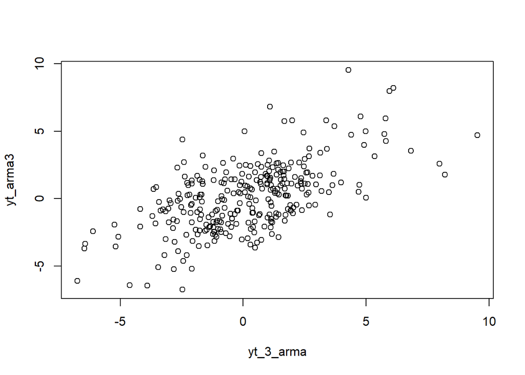

```r
plot(y=yt_arma3,x=yt_3_arma)
```

#### Nilai Korelasi antara $Y_t$ dengan $Y_{t-3}$

```r
cor(yt_arma3,yt_3_arma)
```

```
## [1] 0.6022419
```

hubungan positif yang dilihat pada plot antara $Y_t$ dengan $Y_{t-3}$ juga didukung dengan nilai korelasi sebesar 0.6022419